# Predictability of storm surge and Chesapeake Bay flooding: from days to weeks Notebook

### Original Project Description:

- Run the iFlood SubX forecast system over a period for which SubX re-forecasts have been produced (1999-2015) to evaluate the overall predictability statistics of sea-level predictions at sites along the Chesapeake Bay where historical tide gauge data is available for validation, and the predictability at various lead times for individual events.
- Evaluation of the predictability at the daily, weekly, up to 1-month timescale of the key variables, forecasted by the SubX models, that are needed to force the Mason iFlood system - namely 10-meter winds and sea-level pressure over the western North Atlantic. For this task we will look at the overall predictability statistics for the 1999-2015 re-forecast period over which the global weather and climate models participating in the SubX project have been run. We will evaluate the skill of the multi-model mean as well as the respective model ensembles.

### Testbed Description:

- Testbed using one ensemble member
- SubX Forcing using GEFS ensemble #10
- ADCIRC with EC95 mesh
- Model time step is 20s
- Model run time 35 days
- No tidal signals included
- Using the wind and pressure as a forcing the model is coldstarted
- Global outputs are generated every hour
- Station outputs are generated every 6 minutes
- Simulated time series of surges at NOAA coastal stations
- Observed Time Series of surge at NOAA coastal stations are shown with the simulated surges to be viewed as a reference.
- True is the Re-analysis Winds and Pressure used as forcing for the ADCIRC model
- Error metric #1: Storm surge magnitude bias comparing ensamble member vs control (time period considered 7 days prior/after landfall)

### Discussion Moving Forward:

1. Data "Celso check I forgot this one"
2. New Metric Plots
3. Running all ensembles for Isabel

### Import Libraries and assign variables

```python
import utils
#utils.libs();
root_dir = r'Z:\Project_S2S\3_subx_data\isabel\comparison'
root_dir2 = r'Z:\Project_S2S\3_subx_data\isabel\comparison\no_tidal'
files,tidal,start,nodes,name,stations = utils.files(root_dir,root_dir2)
```

### Locations of Time Series Stations

```python
utils.ec_map()
```

[interactive chart not shown]

## Time Series Surge from Weeks 1-4

- Compare the predictability metrics and skill at various lead times for different types of extreme weather phenomena associated with storm surge events along the mid-Atlantic coast and flooding events in the Chesapeake Bay.
- Shows the surge within 14 days of the Hurricane making landfall.

### Metric 1: Surge Bias Calculations

\begin{align} Bias(dt) = Week_{peak}(dt) - Reanalysis_{peak}(dt) \end{align}

## - Where maximum peak is found within dt=14 days of the Hurricane making landfall

### Duck, NC

[figure not shown]

```python
starts,end,noaa = '20030827','20030926','8651370'
data = utils.plot_timeseries2(files,start,name,26642,starts,end,noaa)
title,x,y = '2003 Hurricane Isabel','Time','Surge(m) at MSL'
layout=utils.layout(title,x,y)
fig = go.Figure(data=data, layout=layout)
interactive = iplot(fig)
#po.plot(fig,filename=root_dir+'\\'+'duck_surge.html')
```

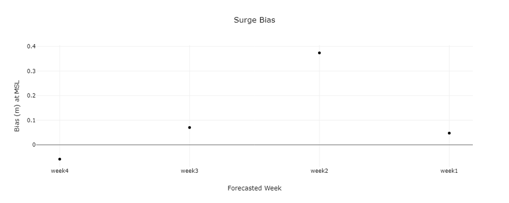

```python
week = ['nan','week4','week3','week2','week1']
data = utils.metric(files,week,start,26642)
title,x,y='Surge Bias','Forecasted Week','Bias (m) at MSL'
layout=utils.layout(title,x,y)
fig = go.Figure(data=data, layout=layout)
interactive = iplot(fig)
#po.plot(fig,filename=root_dir+'\\'+'metric.html')
```

### Lewes, DE

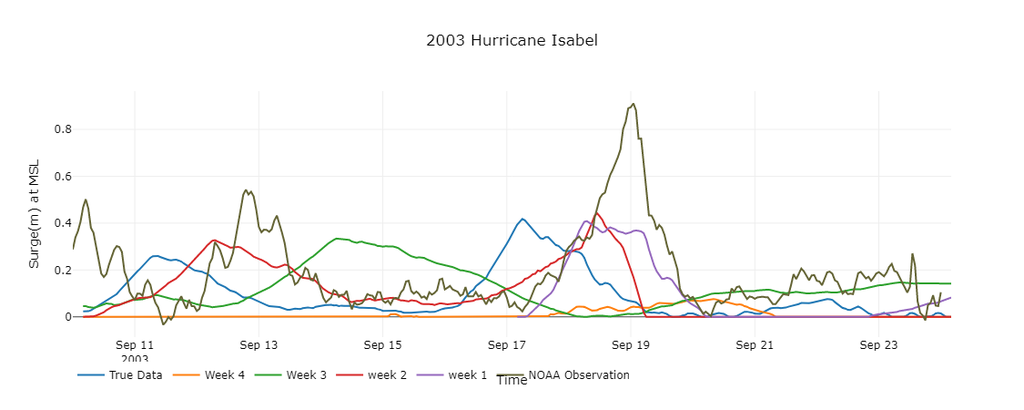

```python
starts,end,noaa = '20030827','20030926','8557380'
data = utils.plot_timeseries2(files,start,name,27921,starts,end,noaa)
title,x,y = '2003 Hurricane Isabel','Time','Surge(m) at MSL'
layout=utils.layout(title,x,y)
fig = go.Figure(data=data, layout=layout)
interactive = iplot(fig)
#po.plot(fig,filename=root_dir+'\\'+'ocean_city_surge.html')
```

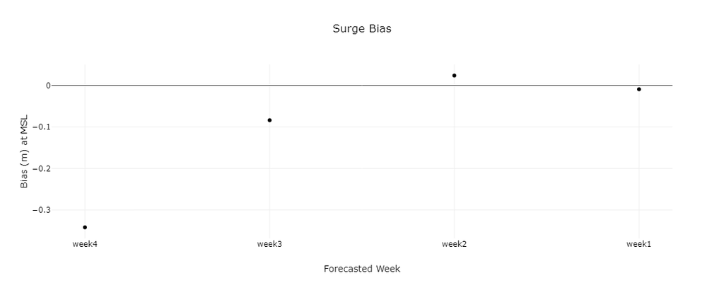

```python
week = ['nan','week4','week3','week2','week1']
data = utils.metric(files,week,start,27921)
title,x,y='Surge Bias','Forecasted Week','Bias (m) at MSL'
layout=utils.layout(title,x,y)
fig = go.Figure(data=data, layout=layout)
interactive = iplot(fig)
#po.plot(fig,filename=root_dir+'\\'+'metric.html')
```

### Ocean City, MD

[figure not shown]

```python
starts,end,noaa = '20030827','20030926','8570283'
data = utils.plot_timeseries2(files,start,name,26720,starts,end,noaa)
title,x,y = '2003 Hurricane Isabel','Time','Surge(m) at MSL'
layout=utils.layout(title,x,y)
fig = go.Figure(data=data, layout=layout)
interactive = iplot(fig)
#po.plot(fig,filename=root_dir+'\\'+'ocean_city_surge.html')
```

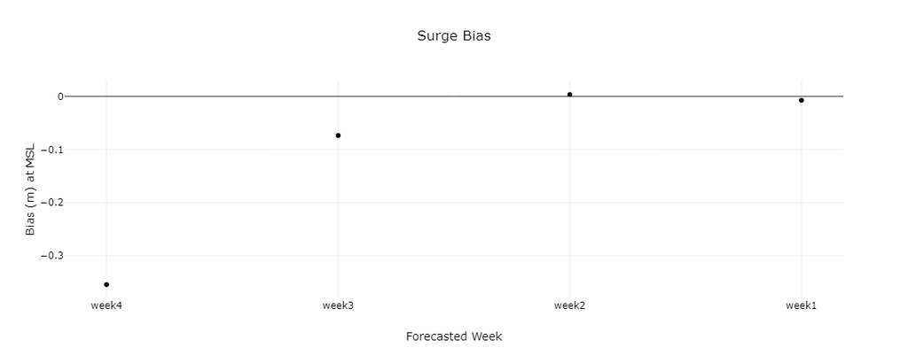

```python
week = ['nan','week4','week3','week2','week1']
data = utils.metric(files,week,start,26720)
title,x,y='Surge Bias','Forecasted Week','Bias (m) at MSL'
layout=utils.layout(title,x,y)
fig = go.Figure(data=data, layout=layout)
interactive = iplot(fig)
#po.plot(fig,filename=root_dir+'\\'+'metric.html')
```

### Atlantic City, NJ

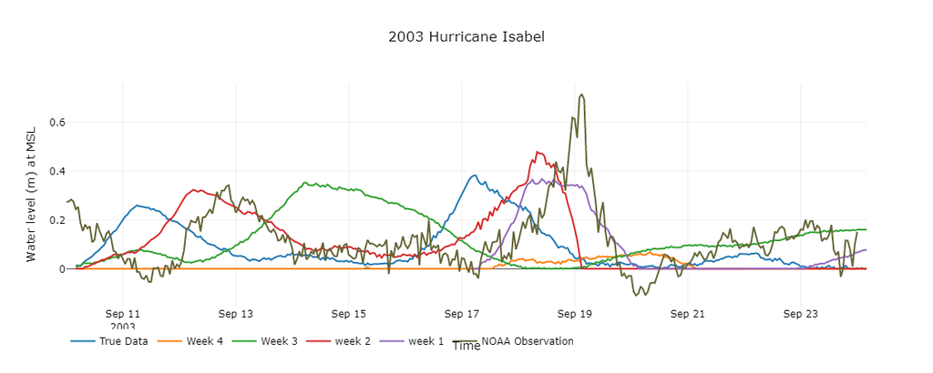

```python
starts,end,noaa = '20030827','20030926','8534720'
data = utils.plot_timeseries2(files,start,name,27226,starts,end,noaa)
title,x,y = '2003 Hurricane Isabel','Time','Water level (m) at MSL'
layout=utils.layout(title,x,y)
fig = go.Figure(data=data, layout=layout)
interactive = iplot(fig)
#po.plot(fig,filename=root_dir+'\\'+'atlantic_city_surge.html')
```

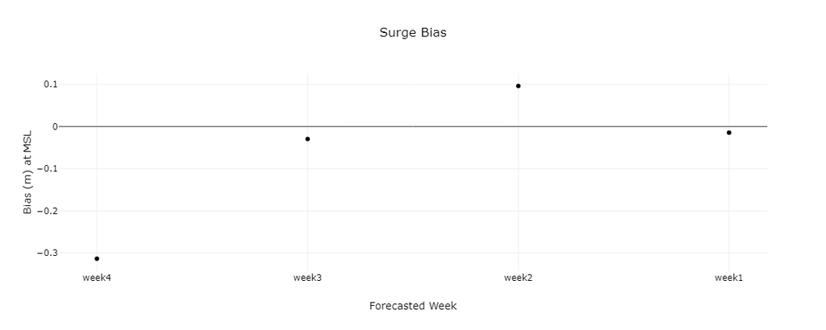

```python
week = ['nan','week4','week3','week2','week1']
data = utils.metric(files,week,start,27226)
title,x,y='Surge Bias','Forecasted Week','Bias (m) at MSL'
layout=utils.layout(title,x,y)
fig = go.Figure(data=data, layout=layout)
interactive = iplot(fig)
#po.plot(fig,filename=root_dir+'\\'+'metric.html')
```

### Wachapreague, VA

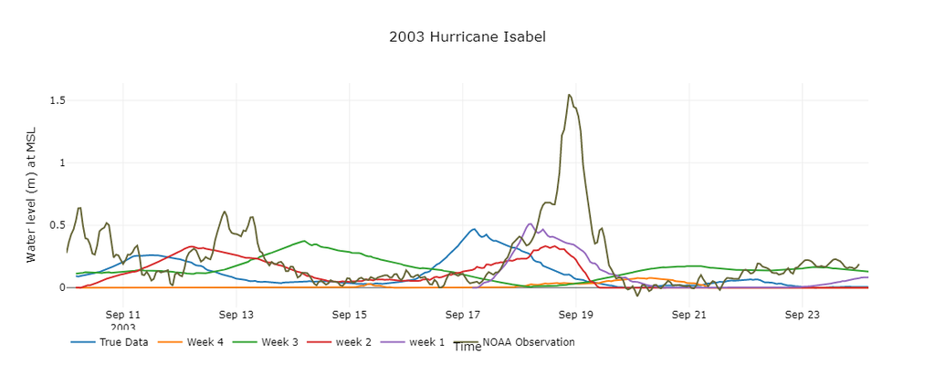

```python
starts,end,noaa = '20030827','20030926','8631044'
data = utils.plot_timeseries2(files,start,name,26981,starts,end,noaa)
title,x,y = '2003 Hurricane Isabel','Time','Water level (m) at MSL'
layout=utils.layout(title,x,y)
fig = go.Figure(data=data, layout=layout)
interactive = iplot(fig)
#po.plot(fig,filename=root_dir+'\\'+'wachapreague_surge.html')
```

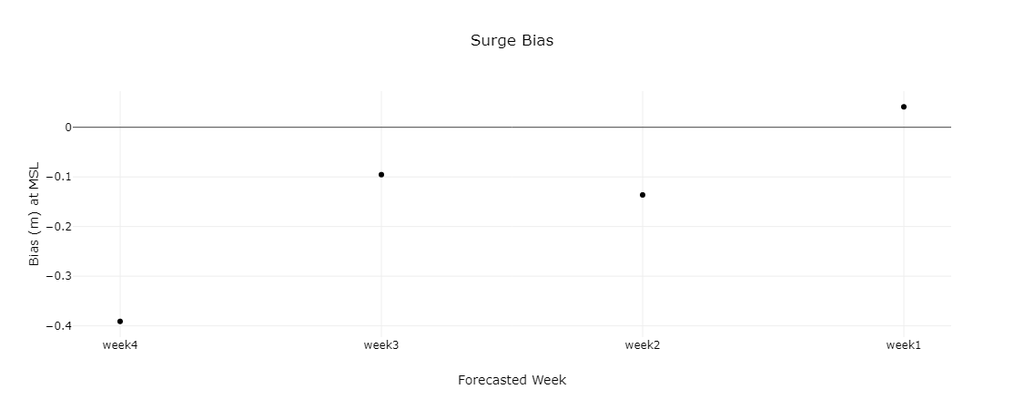

```python
week = ['nan','week4','week3','week2','week1']
data = utils.metric(files,week,start,26981)
title,x,y='Surge Bias','Forecasted Week','Bias (m) at MSL'
layout=utils.layout(title,x,y)
fig = go.Figure(data=data, layout=layout)
interactive = iplot(fig)
#po.plot(fig,filename=root_dir+'\\'+'metric.html')
```

## Time Series of the Global Pressure Outputs

#### True (Re-Analysis) Pressure

[figure not shown]

#### Forecasted Weeks' Pressure

[figure not shown]